# E05: Artificial neural networks in medicine

© *Коллектив авторов, 2023

2023-07-21

**ВСЁ** выделенное курсивом предназначено для пояснения задачи и подлежит удалению (или замене на нужные данные, с убиранием курсива) при формировании окончательного html-документа.

*Данный шаблон (темплет, англ. template) является основой для выполнения практического задания по материалам раздела № 5. Он позволяет выполнить создание простейшей искусственной нейронной сети.*

*После каждой формулировки вопроса, представлен блок кода (чанк) с соответствующими настройками вывода (первая строка в {} скобках, ЕЕ РЕДАКТИРОВАТЬ НЕ НАДО), в который вы должны вставить решение, с использованием языка R. Примеры кода, для решения имеются в соответствующем разделе пособия.*

*Результатом вашей работы должен стать html-документ, содержащий заголовок (в котором необходимо отобразить свои учетные данные - номер факультета, курса, группы, ФИО и т.д.), формулировки вопросов, коды их решения и полученные результаты. В дальнейшем эти html-документы будут объединены в отчет о выполнении индивидуального задания за семестр.*

*Обратите внимание, что в программном коде, приведенном ниже создается подмножество переменных, согласно тех исходных данных, которые вам назначит преподаватель (group == “номер варианта”), поэтому результаты расчетов в большинстве будут отличаться от тех, что получатся у других обучающихся. Этот код не выводится в отчетный документ. Имя формируемого подмножества переменных `MedRecord_nns_XX`, где “ХХ” - номер варианта задаваемого преподавателем. Этот же номер включается в запрос как `group == "ХХ"` для формирования учебного набора данных для конкретного обучаемого. Например, если вариант имеет номер “34”, команда R для отбора данных будет выглядеть следующим образом:*

```
MedRecord_nns_34 <- subset(medrwork::MedRecord, group == "34",
select = c(cid, age, gender, weight, height, lungcap, smoke, HEALTH, TRUD, MILSPECIALTY))
```

*В большинстве вопросов этого задания вы будете брать данные из `MedRecord_nns_XX`. Чанки, относящиеся к вопросам должны содержать написанные вами коды их решения.*

## Практическое задание № 5

**практики**: Научно-исследовательская работа

**на тему:** Искусственный интеллект в статистике: искусственные нейронные сети.

**по специальности:** *Лечебное дело*

## Задание для самостоятельного решения

В поликлинике в/ч № 00000 ведутся записи посещения пациентов приходящих на приём к врачу, а также результаты углубленных медицинских осмотров военнослужащих части в медицинских книжках. Смоделированы исходы “Ощущение нездоровья”. Модель, описывающая наличие ощущения “нездоровья” (переменная `sick`) в зависимости от пола `gender01` ($\beta$=-0,7, т.е. у мужчин ощущение нездоровья меньше, чем у женщин ), возраста `age` ($\beta$=-0.1, на каждый год уменьшение в 1.1 раза, 10%) и оценки (группы) состояния здоровья `HEALTH` ($\beta$=-0.5, в 1.6 раза уменьшается с увеличение на один уровень оценки в худшую сторону) . Увеличение в модели свободного члена (`intercept`) увеличивает долю исходов = 1. Линейный предиктор для переменной исхода `sick`. Построите диаграмму нейронной сети. Постройте графики отражающие процесс моделирования.

Для решения примера воспользуйтесь “Медицинскими записями о здоровье военнослужащих в/ч № 00000 за календарный год” представленые в файле MedRecord.csv в соответствии со своим вариантом.

### Вопрос 1. Сформируйте таблицу исходя из номера вашего варианта для создания набора данных.

```r
install.packages("./medrwork", repos = NULL, type = "source")
install.packages("Hmisc", repos = "https://cloud.r-project.org/")
# Загрузка необходимых библиотек
library(medrwork)
library(Hmisc)

# Создание подмножества данных для варианта 1
MedRecord_nns_1 <- subset(medrwork::MedRecord, group == 1,
                          select = c(gender01, age, HEALTH, p_sick))

# Экспорт подмножества данных в файл CSV
write.csv(MedRecord_nns_1, "./data/MedRecord_nns_1.csv", row.names=FALSE, fileEncoding="UTF-8")

# Импорт набора данных из файла CSV обратно в рабочую среду R
MedRecord_nns_1 <- Hmisc::csv.get("./data/MedRecord_nns_1.csv",
                                  vnames=1, # первая строка в csv - имена переменных
                                  skip=1, # пропуск первой строки (имена переменных)
                                  sep=",", # разделитель в Excel для csv - ","
                                  allow = FALSE) #позволит вам получить исходные имена.

# Просмотр первых строк полученного набора данных
head(MedRecord_nns_1)
```

```
##   gender01 age HEALTH    p_sick
## 1        1  19      2 0.1418511
## 2        0  19      2 0.2890505
## 3        0  19      1 0.4013123
## 4        1  20      1 0.1978161
## 5        1  19      2 0.1418511
## 6        1  23      1 0.1544653
```

### Вопрос 2. Отбор переменных и строк из набора данных для статистического анализа

Напишите *R* код, необходимый для cоздания набора данных для обучения и тестирования нейронной сети и нормализуйте их с помощью функции *scaled*.

```r
# Нормализация данных с помощью функции scale
MedRecord_nns_1_scaled <- as.data.frame(scale(MedRecord_nns_1))

# Просмотр первых строк нормализованного набора данных
head(MedRecord_nns_1_scaled)
```

```
##    gender01        age    HEALTH     p_sick
## 1  0.955953 -1.1902552  0.654919 -0.7738757
## 2 -1.035616 -1.1902552  0.654919  0.8157755
## 3 -1.035616 -1.1902552 -0.768818  2.0281251
## 4  0.955953 -0.7216508 -0.768818 -0.1694922
## 5  0.955953 -1.1902552  0.654919 -0.7738757
## 6  0.955953  0.6841624 -0.768818 -0.6376511
```

### Вопрос 3. Выполните подгонку (обучение) нейронной сети и определите веса в нейронной сети.

Напишите *R* код, необходимый для обучения нейронной сети и определения весов на дугах графа состояния нейронной сети.

```r
# Установка и загрузка необходимых библиотек
install.packages("neuralnet", repos = "https://cloud.r-project.org/")
library(neuralnet)

# Используем нормализованные данные из предыдущего шага
# Предположим, что переменная p_sick является целевой переменной (sick)

# Переименуем переменную p_sick в sick для удобства
MedRecord_nns_1_scaled$sick <- MedRecord_nns_1_scaled$p_sick
MedRecord_nns_1_scaled$p_sick <- NULL

# Просмотр первых строк нормализованного набора данных
head(MedRecord_nns_1_scaled)
```

```
##    gender01        age    HEALTH       sick
## 1  0.955953 -1.1902552  0.654919 -0.7738757
## 2 -1.035616 -1.1902552  0.654919  0.8157755
## 3 -1.035616 -1.1902552 -0.768818  2.0281251
## 4  0.955953 -0.7216508 -0.768818 -0.1694922
## 5  0.955953 -1.1902552  0.654919 -0.7738757
## 6  0.955953  0.6841624 -0.768818 -0.6376511
```

```r
# Определение формулы для нейронной сети
formula <- sick ~ gender01 + age + HEALTH

# Обучение нейронной сети
set.seed(123) # Установка начального значения для воспроизводимости результатов
nn <- neuralnet(formula, data = MedRecord_nns_1_scaled, hidden = c(5, 3), linear.output = FALSE)

# Определение весов в нейронной сети
nn$weights
```

```
## [[1]]
## [[1]][[1]]
##           [,1]       [,2]      [,3]     [,4]      [,5]
## [1,] 0.7498303  0.4018592 0.2703484 1.237044 -2.059351
## [2,] 2.0517053  0.6255632 1.8362208 2.330065 -3.379433
## [3,] 1.2974356 -2.3974867 1.0756582 1.130212 -1.605620
## [4,] 1.3089852 -3.3483074 1.3888637 1.679060 -2.436449
##
## [[1]][[2]]
##            [,1]      [,2]      [,3]
## [1,] -0.9059687 -0.746680 -1.343019
## [2,]  2.6606938  2.999642  2.816121
## [3,] -0.9700210 -2.734905 -1.146965
## [4,]  2.2381806  3.476746  2.506786
## [5,]  2.3926824  3.393536  2.460467
## [6,] -4.2578589 -2.817739 -3.137372
##
## [[1]][[3]]
##           [,1]
## [1,]  7.084082
## [2,] -7.611133
## [3,] -6.318177
## [4,] -4.913429
```

### Вопрос 4. Постройте диаграмму нейронной сети.

Напишите *R* код, необходимый для графического постоения графа состояния отображающего нейронную сеть.

```r
# Установка и загрузка необходимых библиотек
install.packages("neuralnet", repos = "https://cloud.r-project.org/")
library(neuralnet)

# Импорт набора данных из файла CSV обратно в рабочую среду R
MedRecord_nns_1 <- read.csv("./data/MedRecord_nns_1.csv", fileEncoding="UTF-8")

# Нормализация данных с помощью функции scale
MedRecord_nns_1_scaled <- as.data.frame(scale(MedRecord_nns_1))

# Переименуем переменную p_sick в sick для удобства
MedRecord_nns_1_scaled$sick <- MedRecord_nns_1_scaled$p_sick
MedRecord_nns_1_scaled$p_sick <- NULL

# Просмотр первых строк нормализованного набора данных
head(MedRecord_nns_1_scaled)
```

```
##    gender01        age    HEALTH       sick
## 1  0.955953 -1.1902552  0.654919 -0.7738757
## 2 -1.035616 -1.1902552  0.654919  0.8157755
## 3 -1.035616 -1.1902552 -0.768818  2.0281251
## 4  0.955953 -0.7216508 -0.768818 -0.1694922
## 5  0.955953 -1.1902552  0.654919 -0.7738757
## 6  0.955953  0.6841624 -0.768818 -0.6376511
```

```r
# Определение формулы для нейронной сети
formula <- sick ~ gender01 + age + HEALTH

# Обучение нейронной сети
set.seed(123) # Установка начального значения для воспроизводимости результатов
nn <- neuralnet(formula, data = MedRecord_nns_1_scaled, hidden = c(5, 3), linear.output = FALSE)

# Визуализация нейронной сети
plot(nn, rep = "best")
```

[output not shown]

### Вопрос 5. Преобразуйте вероятности в бинарные классы с установкой порогового уровня.

Напишите *R* код, необходимый для преобразования бинарных классов нейронной сети и установления порогового значения

```r
# Установка и загрузка необходимых библиотек
install.packages("neuralnet", repos = "https://cloud.r-project.org/")
library(neuralnet)

# Импорт набора данных из файла CSV обратно в рабочую среду R
MedRecord_nns_1 <- read.csv("./data/MedRecord_nns_1.csv", fileEncoding="UTF-8")

# Нормализация данных с помощью функции scale
MedRecord_nns_1_scaled <- as.data.frame(scale(MedRecord_nns_1))

# Переименуем переменную p_sick в sick для удобства
MedRecord_nns_1_scaled$sick <- MedRecord_nns_1_scaled$p_sick
MedRecord_nns_1_scaled$p_sick <- NULL

# Просмотр первых строк нормализованного набора данных
head(MedRecord_nns_1_scaled)
```

```
##    gender01        age    HEALTH       sick
## 1  0.955953 -1.1902552  0.654919 -0.7738757
## 2 -1.035616 -1.1902552  0.654919  0.8157755
## 3 -1.035616 -1.1902552 -0.768818  2.0281251
## 4  0.955953 -0.7216508 -0.768818 -0.1694922
## 5  0.955953 -1.1902552  0.654919 -0.7738757
## 6  0.955953  0.6841624 -0.768818 -0.6376511
```

```r
# Определение формулы для нейронной сети
formula <- sick ~ gender01 + age + HEALTH

# Обучение нейронной сети
set.seed(123) # Установка начального значения для воспроизводимости результатов
nn <- neuralnet(formula, data = MedRecord_nns_1_scaled, hidden = c(5, 3), linear.output = FALSE)

# Визуализация нейронной сети
plot(nn, rep = "best")
```

[output not shown]

```r
# Получение предсказаний от обученной нейронной сети
predictions <- compute(nn, MedRecord_nns_1_scaled[, c("gender01", "age", "HEALTH")])$net.result

# Установка порогового значения
threshold <- 0.5

# Преобразование вероятностей в бинарные классы
binary_predictions <- ifelse(predictions > threshold, 1, 0)

# Просмотр первых строк бинарных предсказаний
head(binary_predictions)
```

```
##      [,1]
## [1,]    0
## [2,]    1
## [3,]    1
## [4,]    0
## [5,]    0
## [6,]    0
```

### Вопрос 6. Выполните этап прогнозирования с использованием нейросети.

Напишите *R* код, необходимый для выполнения этапа прогнозирования и установления порогового значения

```r
# Установка и загрузка необходимых библиотек
install.packages("neuralnet", repos = "https://cloud.r-project.org/")
library(neuralnet)

# Импорт набора данных из файла CSV обратно в рабочую среду R
MedRecord_nns_1 <- read.csv("./data/MedRecord_nns_1.csv", fileEncoding="UTF-8")

# Нормализация данных с помощью функции scale
MedRecord_nns_1_scaled <- as.data.frame(scale(MedRecord_nns_1))

# Переименуем переменную p_sick в sick для удобства
MedRecord_nns_1_scaled$sick <- MedRecord_nns_1_scaled$p_sick
MedRecord_nns_1_scaled$p_sick <- NULL

# Определение формулы для нейронной сети
formula <- sick ~ gender01 + age + HEALTH

# Обучение нейронной сети
set.seed(123) # Установка начального значения для воспроизводимости результатов
nn <- neuralnet(formula, data = MedRecord_nns_1_scaled, hidden = c(5, 3), linear.output = FALSE)

# Визуализация нейронной сети
plot(nn, rep = "best")
```

[output not shown]

```r
# Получение предсказаний от обученной нейронной сети
predictions <- compute(nn, MedRecord_nns_1_scaled[, c("gender01", "age", "HEALTH")])$net.result

# Установка порогового значения
threshold <- 0.5

# Преобразование вероятностей в бинарные классы
binary_predictions <- ifelse(predictions > threshold, 1, 0)

# Просмотр первых строк бинарных предсказаний
head(binary_predictions)
```

```
##      [,1]
## [1,]    0
## [2,]    1
## [3,]    1
## [4,]    0
## [5,]    0
## [6,]    0
```

```r
# Добавление предсказаний к исходным данным для анализа
MedRecord_nns_1_scaled$predicted_sick <- binary_predictions

# Просмотр первых строк данных с предсказаниями
head(MedRecord_nns_1_scaled)
```

```
##    gender01        age    HEALTH       sick predicted_sick
## 1  0.955953 -1.1902552  0.654919 -0.7738757              0
## 2 -1.035616 -1.1902552  0.654919  0.8157755              1
## 3 -1.035616 -1.1902552 -0.768818  2.0281251              1
## 4  0.955953 -0.7216508 -0.768818 -0.1694922              0
## 5  0.955953 -1.1902552  0.654919 -0.7738757              0
## 6  0.955953  0.6841624 -0.768818 -0.6376511              0
```

### Вопрос 7. Постройте график зависимости прогнозируемых значений от реальных.

Напишите *R* код, необходимый для построения графика зависимости прогнозируемых значений от реальных значений выработки решений нейронной сетью.

```r
# Установка и загрузка необходимых библиотек
install.packages("neuralnet", repos = "https://cloud.r-project.org/")
library(neuralnet)

# Импорт набора данных из файла CSV обратно в рабочую среду R
MedRecord_nns_1 <- read.csv("./data/MedRecord_nns_1.csv", fileEncoding="UTF-8")

# Нормализация данных с помощью функции scale
MedRecord_nns_1_scaled <- as.data.frame(scale(MedRecord_nns_1))

# Переименуем переменную p_sick в sick для удобства
MedRecord_nns_1_scaled$sick <- MedRecord_nns_1_scaled$p_sick
MedRecord_nns_1_scaled$p_sick <- NULL

# Определение формулы для нейронной сети
formula <- sick ~ gender01 + age + HEALTH

# Обучение нейронной сети
set.seed(123) # Установка начального значения для воспроизводимости результатов
nn <- neuralnet(formula, data = MedRecord_nns_1_scaled, hidden = c(5, 3), linear.output = FALSE)

# Визуализация нейронной сети
plot(nn, rep = "best")
```

[output not shown]

```r
# Получение предсказаний от обученной нейронной сети
predictions <- compute(nn, MedRecord_nns_1_scaled[, c("gender01", "age", "HEALTH")])$net.result

# Установка порогового значения
threshold <- 0.5

# Преобразование вероятностей в бинарные классы
binary_predictions <- ifelse(predictions > threshold, 1, 0)

# Просмотр первых строк бинарных предсказаний
head(binary_predictions)
```

```
##      [,1]
## [1,]    0
## [2,]    1
## [3,]    1
## [4,]    0
## [5,]    0
## [6,]    0
```

```r
# Добавление предсказаний к исходным данным для анализа
MedRecord_nns_1_scaled$predicted_sick <- binary_predictions

# Просмотр первых строк данных с предсказаниями
head(MedRecord_nns_1_scaled)
```

```
##    gender01        age    HEALTH       sick predicted_sick
## 1  0.955953 -1.1902552  0.654919 -0.7738757              0
## 2 -1.035616 -1.1902552  0.654919  0.8157755              1
## 3 -1.035616 -1.1902552 -0.768818  2.0281251              1
## 4  0.955953 -0.7216508 -0.768818 -0.1694922              0
## 5  0.955953 -1.1902552  0.654919 -0.7738757              0
## 6  0.955953  0.6841624 -0.768818 -0.6376511              0
```

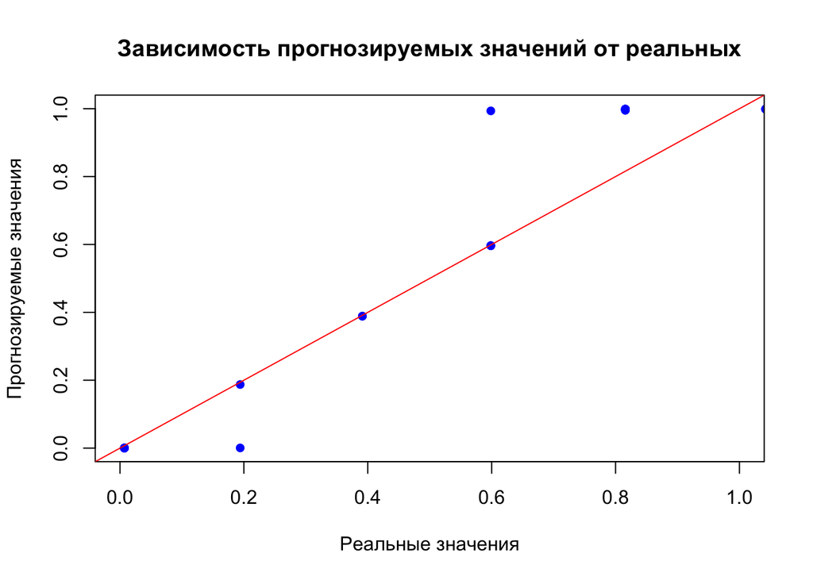

```r
# Построение графика зависимости прогнозируемых значений от реальных
plot(MedRecord_nns_1_scaled$sick, predictions,
     xlab = "Реальные значения", ylab = "Прогнозируемые значения",
     main = "Зависимость прогнозируемых значений от реальных",
     col = "blue", pch = 16, xlim = c(0, 1), ylim = c(0, 1))
abline(0, 1, col = "red")
```

## Справочные материалы

Для выполнения задания Вы можете использовать R коды из материалов соответствующего раздела.